# Final_Project

Ifeh Akano

4/19/2021

# Introduction

## Chromatin can adopt active or repressive states to tightly regulate transcription

### The basic unit of eukaryotic chromatin consists of genomic DNA tightly wound around octamers of the core histones – H2A, H2B, H3, and H4 – to form nucleosome core particles (NCPs).(Allis and Jenuqein 2001) Alterations in chromatin accessibility play a crucial role in all DNA-templated processes, and the dynamic nature of chromatin structure is tightly controlled by epigenetic ‘marks’, such as DNA methylation and histone post-translational modifications (PTMs). Histone ubiquitination is distinct from other histone PTMs, such as acetylation and methylation, because it involves the covalent conjugation of a 76-amino acid ubiquitin protein onto a lysine residue via a three-part cascade consisting of: E1 activating, E2 conjugating, and E3 ligase enzymes. Since its discovery, it has become increasingly apparent that histone ubiquitination plays essential roles in DNA repair, nucleosome dynamics, and participation in ‘crosstalk’ with other PTMs.(Workman and Weake 2008) Notably, recent proteomics studies have identified an extensive number of novel ubiquitination sites on all four of the core histones, as well as the linker histone H1.(Huang et al. 2014) The vast majority of histone ubiquitination sites, however, remain uncharacterized. The evident importance of histone ubiquitination in the maintenance of genomic integrity provides rationale for studying novel histone E3 ligases.

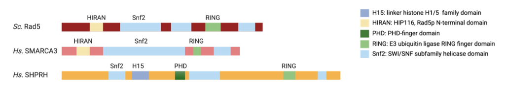

```r
knitr::include_graphics("/Users/ifehakano/Documents/ANGSD/SHPRH.png")
```

## The unique domain architecture of the E3 ligase SHPRH suggests roles in chromatin modulation, but SHPRH is largely unstudied

### The multi-domain E3 ligase SHPRH (SNF2-histone linker-PHD-RING-helicase) has a well-characterized role in mediating an error-free branch of post-replication repair.(Unk et al. 2010) SHPRH is one of two mammalian homologues of yeast Rad5, the other being SMARCA3, all known to promote the regression and restart of stalled DNA replication forks through ubiquitination of the proliferating-cell nuclear antigen (PCNA) sliding clamp.(Unk et al. 2010) Literature shows that loss of SHPRH or SMARCA3 increases genomic instability following DNA damage.12 SMARCA3 and SHPRH have been shown to act in UV or methyl methane sulfonate (MMS) damage-specific manners, respectively, the latter promoting the recruitment of damage-specific polymerases.(Lin et al. 2012) These mechanisms are mediated by the SNF2 and RING domains of SHPRH and SMARCA3, conserved features between all three homologues (Figure 1). In stark contrast to its homologues, SHPRH has evolved to also harbor a histone-binding PHD and an uncharacterized H15 domain, which shows homology to the globular domain of the linker histone H1.(Unk et al. 2010) This unique domain architecture led Brühl et al. to investigate the biochemical activity of SHPRH in the presence of nucleosomal substrates. Indeed, they demonstrate robust ubiquitination of histones H3 and H4 in vitro by SHPRH with novel E2 pairs.(Bruhl et al. 2019) Moreover, recent literature suggests that SHPRH interacts with histone H3 by its PHD to regulate the transcription of ribosomal RNA (rRNA) in the nucleoli.(Lee et al. 2017) While these findings were encouraging, a detailed understanding of the activity of SHPRH on chromatin and its downstream implications remain unknown. I hypothesize that SHPRH regulates gene expression through epigenetic alterations in chromatin accessibility, and that its roles in transcriptional regulation are not limited to ribosomal biogenesis.

# Results

### These data were kindly analyzed by Dr. Richard Koche at MSKCC. The data from this analysis suggests a global transcriptional rewiring and opening of chromatin upon cellular depletion of SHPRH. Moving forward, I plan to observe the role of SHPRH in regulating chromatin biology in a more relevant model of human disease, such as cancer cell lines or organoids. Furthermore, a big limitation of this experiment is that I performed bulk-RNA- and ATAC-seq, which comes with many caveats. It would be interesting to perform single-cell RNA-seq and compare the results to the general trend observed here. A potential bias in this experiment is the limitation in replicates. It is favorable to have at least six replicates, and I only have three. This could lead to potential biases when interpreting the data, and I may consider redoing the experiment. It’s also interesting to note the vast differences between the two knockout cell lines, which could be attributed to the different mutations produced by the CRISPR technology, either homozygous or heterozygous. Another limitation of this experiment, is that I cannot ignore the role that SHPRH plays in DNA repair, and this experiment does not separate the role of SHPRH on chromatin from its mechanism in DNA repair. It is likely that cellular depletion of SHPRH significantly alters the genomic integrity of the 293T cells, leading to a disrupted transcriptional profile. Proper controls are needed to elucidate the dependency, or lackthereof, of these distinct SHPRH functions.

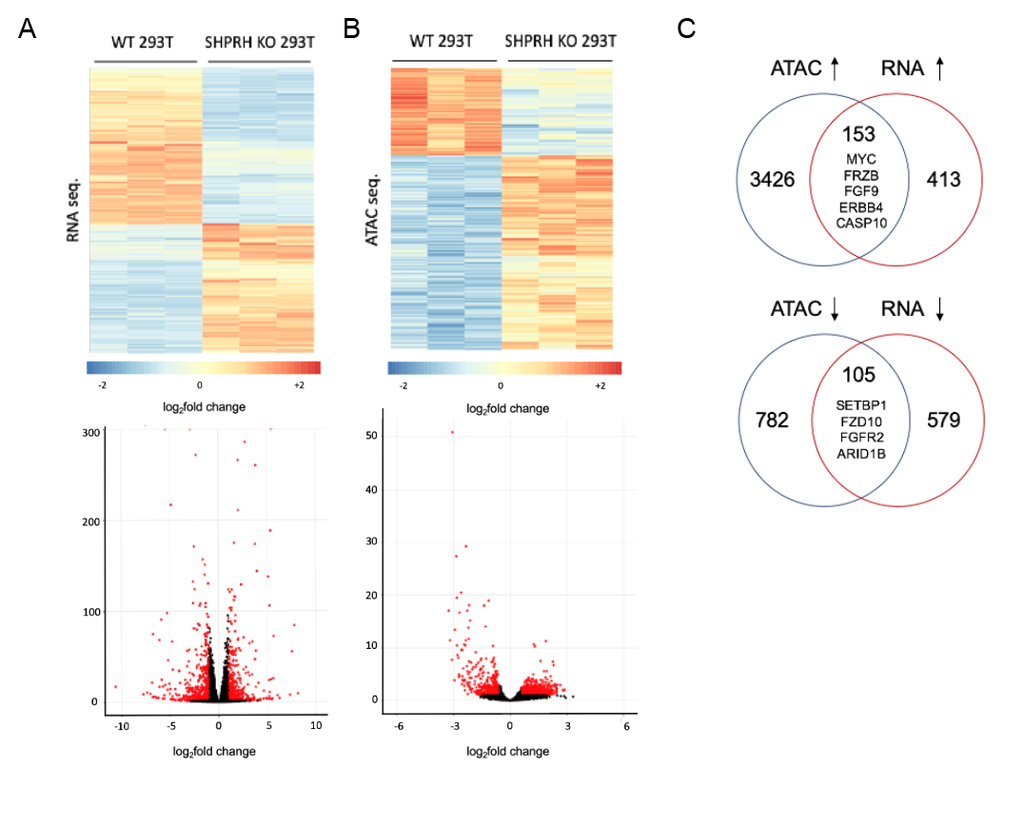

```r
knitr::include_graphics("/Users/ifehakano/Documents/ANGSD/Figure2_ANGSD.png")
```

## QC

### These data are very high quality and statistically significant analysis. FastQC analysis confirmed no need for trimming, with less than 0.1% adapter content and no significantly overrepresented sequences. The FastQC sequence counts show a large number of duplicate reads, resulting in approximately 20M unique reads per sample. The per sequence GC content is relatively consistent across all samples at about 50% GC content. The STAR alignment scores show 90% of reads uniquely mapped for all samples, and feature counting show approximately 76% of assigned features. In conclusion, these data exhibit exceptional QC analysis and readiness to proceed to DESeq analysis.

## Cellular depletion of SHPRH leads to a global transcriptional rewiring in HEK 293T cells

### These data suggest that SHPRH plays a crucial role in the regulation of proper gene expression. This could be attributed to its histone ubiquitination activity, ribosomal RNA transcription activity, chromatin remodeling activity, and/or DNA repair activity. Furthermore, I predict that SHPRH could have alternative functions in the cell, given these drastic genomic changes upon cellular depletion. Interestingly, I did not observe a substantial number of ribosomal proteins in the RNA-seq hits. This suggests that the role of SHPRH in regulating rRNA transcription is only a small fraction of its functions in the cell.

# Methods

## Sample preparation, data acquisition, and sequencing

### Downloading samples

```bash
# I first had to log into the IGO MSK server and load the files into my scratch folder.
cd /Volumes/Davidshy/Project_11231_B
rsync -ar --progress Project_11231_B ifa4001@aphrodite.med.cornell.edu:/athena/angsd/scratch/ifa4001/
```

## Alignment and QC

### Before aligning the raw reads to the genome, I first performed fastqc and determined no significant overrepresented sequences or adapter content and therefore no need for trimming.

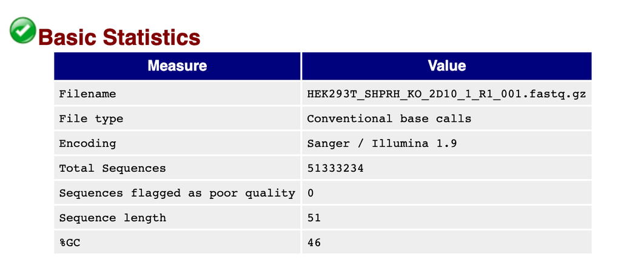

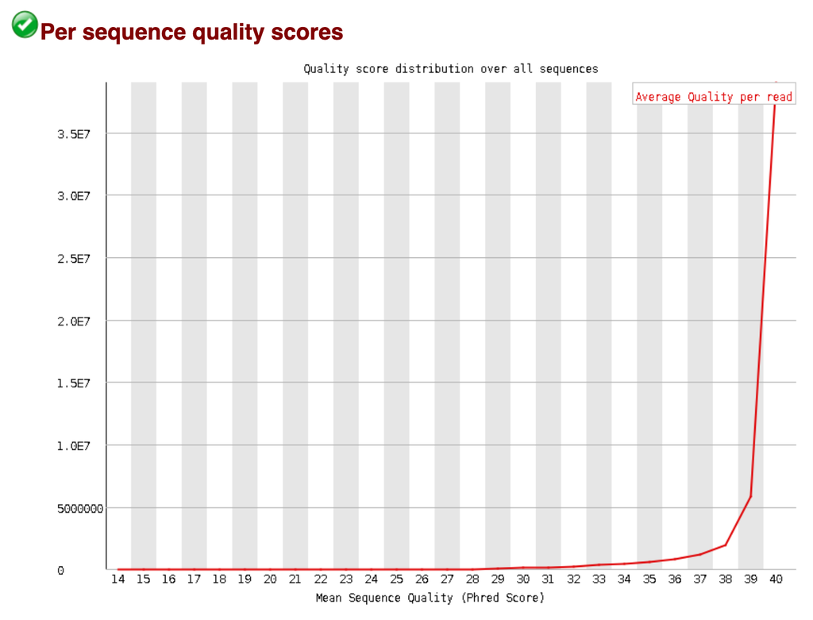

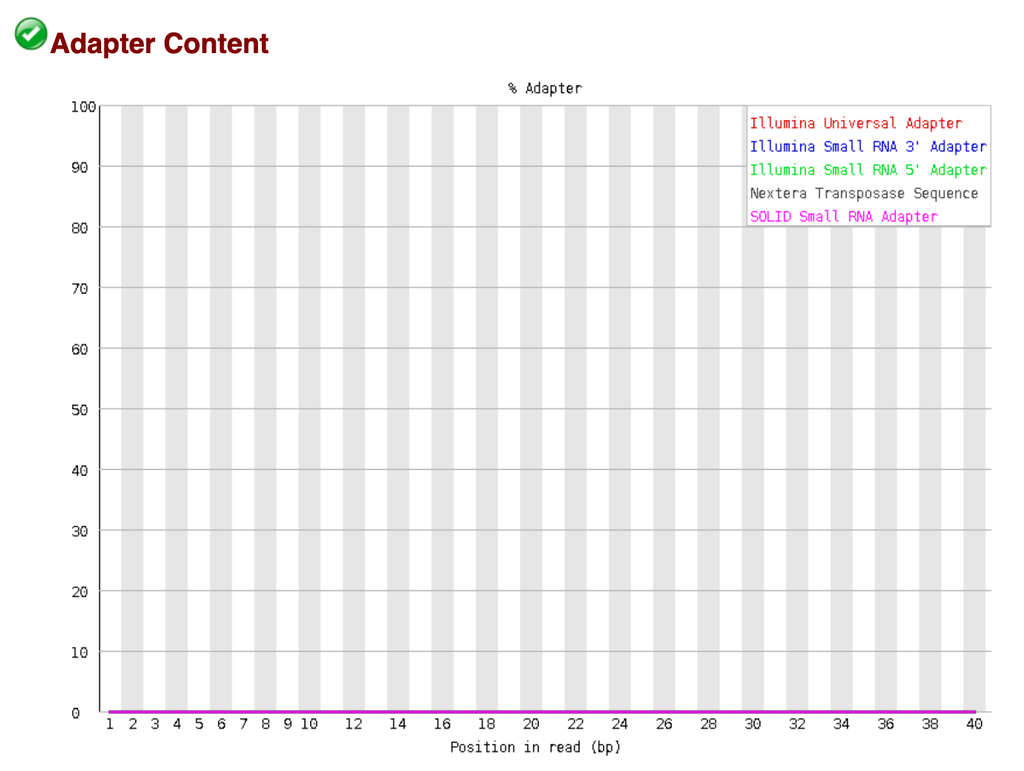

```r
knitr::include_graphics(c("/Users/ifehakano/Desktop/Screen Shot 2021-02-26 at 9.30.27 PM.png","/Users/ifehakano/Desktop/Screen Shot 2021-02-26 at 9.31.32 PM.png", "/Users/ifehakano/Desktop/Screen Shot 2021-02-26 at 9.35.05 PM.png"))
```